# ISL5(Resampling Methods)

# Resampling methods

하나의 데이터에서 반복적으로 sample을 만들어 model을 적합시켜 보는 것. 하나의 training set에 모델을 적합 시킬 때보다 더 많은 정보를 얻을 수 있다. 여러개의 샘플을 사용해 회귀를 적합해보면 추정치가 어느정도의 범위에 있을지 알 수 있다. 근데 일반적으로 우리가 가지고 있는 샘플은 하나.. 그래서 나온 것이 resampling

[대표적인 방법 두가지]

1. **cross-validation**
   - 데이터를 train/validation으로 쪼개서 모델을 여러개의 validation MSE를 구한다
   - test set을 구할 수 없는 상황에서 test MSE를 추정하기 위해 validation set을 사용하는 것!
2. **bootstrap**
   - 우리가 가지고 있는 data에서 복원추출로 샘플을 계속 뽑아 추론하는 방법

# 1. cross-validation

- 모델의 최종목적 test error를 줄이는 것(내가 아는 데이터로 모델을 만들어서 모르는 데이터가 들어왔을 때 얼마나 잘 예측하는가). 하지만 test data를 가지고 있지 않은 경우가 다수 ex 내일 주식 예측, 이번연도 말에 있는 KBO 경기의 승률을 예측하는 경우
- 우리가 이미 가지고 있는 데이터를 나눠서 그 일부를 test data처럼 사용. validation set을 통해 validation MSE를 구하고 이를 test MSE의 추정치로 사용하자
- 우리가 가지고 있는 데이터를 최대한 활용하자!!

## 1.1 the validation set approach : 데이터를 반반 쪼개자

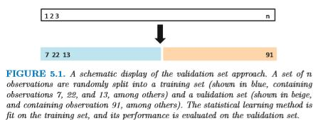

pic1.jpg

- 데이터를 random하게 반으로 잘라서 train set validation set으로 나누는 방법으로 이 과정을 반복하면 여러개의 Validation MSE를 구할 수 있다

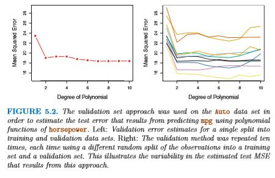

pic2.jpg

- 오른쪽의 그림은 데이터를 나누는 것을 10번 반복해서 얻는 validation set MSE. 10개의 MSE 모두 1차항에서 2차항으로 넘어갈 때 MSE가 확연하게 줄고, 그 이후의 고차항을 사용하는 것이 큰 이득이 없음을 확인할 수 있다
- 여기서 나타나는 문제점 두가지:
  1. 어떤 데이터가 validation set에 포함되어 있는지에 따라서 추정된 test MSE의 변동이 너무 크다 > 추정치로 사용하기에는 무리가 있음
  2. 가지고 있는 데이터의 반만 사용해 fitting을 하기 때문에 validation MSE가 큰 값을 가질 수 있다(Bias가 커진다). 즉 Test MSE를 overestimate하게 된다.

## 1.2 Leave - One - Out Cross Validation (LOOCV) : 데이터를 하나 남기고 사용하자

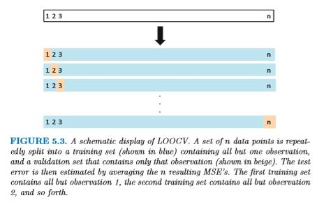

pic3.jpg

- validation set approach에서 발생한 단점을 줄이고자, train data의 양을 늘림
- 전체 데이터에서 하나의 데이터만 제외해 n-1개의 데이터로 모델을 fitting한 후, 하나의 데이터에 대해서 MSE를 구한다. 이 과정을 반복해서 얻는 n개의 MSE 평균을 Test MSE의 추정치로 사용

$$CV(n) = \dfrac{1}{N} \sum^{N}_{i=1} MSE_i$$

- 장점
  1. 데이터를 반만 사용하던 validation set approach와 달리 n-1개의 데이터를 사용해 모델을 fitting하기 때문에 bias가 적다. 즉 test MSE를 overestimate하지 않는다
  2. 추정치n개의 값에 대한 평균을 test MSE의 추정치로 사용하기 때문에 Training/ validation 구분에 따라 추정치가 달라질 일이 없다
  3. OLS 회귀분석에서는 n번의 과정을 반복할 필요없이 아래의 식을 통해 한번에 test MSE의 추정치를 구할 수 있다
     $$CV(n) = \dfrac{1}{N} \sum^{N}_{i=1} (\frac{y_i-\hat{y_i}}{1-h_{ii}})^2$$
     증명은 뒷부분 참고!
- 단점
  1. 일반적으로는 n번을 반복해서 fitting을 해야하기 때문에 n이 커지면 fitting을 하는데 시간이 오래 걸린다
     - 그러면 n번 반복하지 말고 k번 반복하자 : **K-fold cross validation**
  2. LOOCV는 n-1개의 데이터로 모델을 fitting하기 때문에 bias가 낮지만 높은 variance를 가지고 있다.
     - 왜? 1개의 데이터를 제외하고 fitting을 해서 생성된 n개의 모델들은 서로 높은 correlation을 가지고 있기 때문에

## 1.3 K-Fold Cross Validation : K개의 그룹으로 나누자

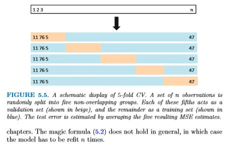

pic5.jpg

- 전체 데이터를 k개의 그룹으로 랜덤하게 나누고, k-1개의 그룹을 통해 모델을 fitting하고 그 나머지 그룹을 validation set으로 활용하는 방법
- k개의 MSE를 구해서 그 평균값을 Test MSE의 추정치로 사용한다
- K값은 주로 5나 10을 사용한다고 한다
  $$CV(n) = \dfrac{1}{k} \sum^{k}_{i=1} MSE_i$$
- 장점
  1. LOOCV보다 연산속도가 더 빠르다
  2. Test MSE 추정치의 분산이 더 줄어든다 : bias - variance trade off 관계
     - 이러한 점에서 LOOCV보다 더 개선된 방법이라고 볼 수 있다

## 1.4 Bias - variance Trade Off

- bias: Training set의 데이터가 많을수록 모델의 bias가 줄어든다
  - the validation approach는 반개의 데이터만 활용해서 bias가 큰 반면에 LOOCV와 K-fold cross validations는 상대적으로 작은 bias를 갖는다
- Variance: LOOCV가 하나의 데이터만 제외하고 fitting을 한 것이기 때문에 n개의 fitting 결과가 거의 동일하다.
  - 수학적으로 이해하면 Variance를 구할 때 MSE의 공분산 값이 포함되는데, correlation이 높아지면 분산이 커짐
    $$Var(CV(k)) = VAR(\dfrac{1}{k} MSE_1 + \dfrac{1}{k} MSE_2 + ... + \dfrac{1}{k} MSE_K)$$
    $$= \dfrac{1}{k^2}[VAR(MSE_1) + VAR(MSE_2) + ... + VAR(MSE_K)+ ... + \sum^{}_{i=/=j} COV(MSE_i,MSE_J)]$$
  - 다른 데이터 셋으로 Loocv를 구하면 값이 많이 달라진다.

# 2. BootStrap

- Bootstrap은 통계학에서 복원추출을 의미. 우리가 가지고 있는 데이터에서 복원추출을 하여 여러개의 샘플을 만드는 방법
- 우리가 모수 $\theta$에 대한 추정을 하고자 할 때, $\hat{\theta}$ 에 대한 분포를 모른다고 하자. 이 때 데이터에서 복원추출을 하여 여러개의 sample을 만들고 각 sample에서 $\hat{\theta_1}$, $\hat{\theta_2}$,…, $\hat{\theta_n}$을 생성해 bootstrap분포를 구할 수 있다. 이렇게 구한 bootstrap 분포가 모집단의 분포에 근사하게 된다(단 각각의 값이 iid 만족해야 함)

[예시]

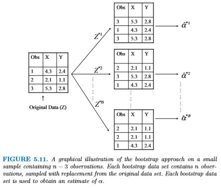

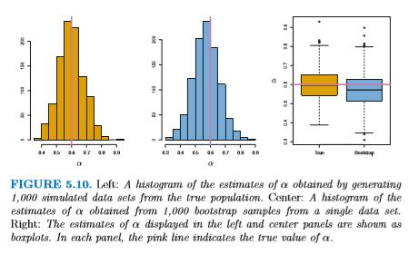

- 1000개의 bootstrap sample을 뽑아 그 분포를 구했더니, 모분포에 근사한다는 것을 확인할 수 있다 > 부트스트랩은 매우 유용!!

참고자료 : An Introduction to statistical Learning : with Applications in R